# 算法训练营Day 35 - 动态规划 part04

Author

Siru Wu

Published

March 1, 2026

## [1049.最后一块石头的重量II](https://leetcode.cn/problems/last-stone-weight-ii/description/)

> 有一堆石头，用整数数组 stones 表示。其中 stones[i] 表示第 i 块石头的重量。

> 每一回合，从中选出任意两块石头，然后将它们一起粉碎。假设石头的重量分别为 x 和 y，且 x <= y。那> 么粉碎的可能结果如下：
> - 如果 x == y，那么两块石头都会被完全粉碎；
> - 如果 x != y，那么重量为 x 的石头将会完全粉碎，而重量为 y 的石头新重量为 y-x。

> 最后，最多只会剩下一块 石头。返回此石头 最小的可能重量 。如果没有石头剩下，就返回 0。

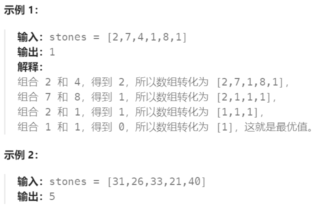

```python
class Solution:
    def lastStoneWeightII(self, stones: List[int]) -> int:
        total_sum = sum(stones)
        target = total_sum // 2

        dp = [0] * (target + 1)

        for stone in stones:
            for j in range(target, stone -1, -1):
                dp[j] = max(dp[j], dp[j - stone] + stone)

        return total_sum - 2 * dp[-1]
        # S2 - S1
        # = total_sum - S1 - S1
        # = total_sum - 2*S1
```

## [494.目标和](https://leetcode.cn/problems/target-sum/description/)

> 给你一个非负整数数组 nums 和一个整数 target 。

> 向数组中的每个整数前添加 ‘+’ 或 ‘-’ ，然后串联起所有整数，可以构造一个 表达式 ：
> - 例如，nums = [2, 1] ，可以在 2 之前添加 ‘+’ ，在 1 之前添加 ‘-’ ，然后串联起来得到表达式 “+2-1” 。

> 返回可以通过上述方法构造的、运算结果等于 target 的不同 表达式 的数目。

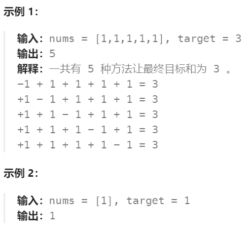

```python
class Solution:
    def findTargetSumWays(self, nums: List[int], target: int) -> int:
        total_sum = sum(nums)  # 计算nums的总和
        if abs(target) > total_sum:
            return 0  # 此时没有方案
        if (target + total_sum) % 2 == 1: # target + sum(nums) 必须是偶数才能让 P 是个正整数
            # P - N = target
            # P + N = sum(nums)
            # 2P = target + sum(nums)
            # P = (target + sum(nums)) / 2
            return 0  # 此时没有方案
        target_sum = (target + total_sum) // 2  # 目标和
        dp = [0] * (target_sum + 1)  # 创建动态规划数组，初始化为0，什么都不选，组成 0 的方法有 1 种。
        dp[0] = 1  # 当目标和为0时，只有一种方案，即什么都不选
        for num in nums:
            for j in range(target_sum, num - 1, -1):
                dp[j] += dp[j - num]  # 状态转移方程，累加不同选择方式的数量
        return dp[target_sum]  # 返回达到目标和的方案数
```

## [474.一和零](https://leetcode.cn/problems/ones-and-zeroes/description/)

> 给你一个二进制字符串数组 strs 和两个整数 m 和 n 。

> 请你找出并返回 strs 的最大子集的长度，该子集中 最多 有 m 个 0 和 n 个 1 。

> 如果 x 的所有元素也是 y 的元素，集合 x 是集合 y 的 子集 。

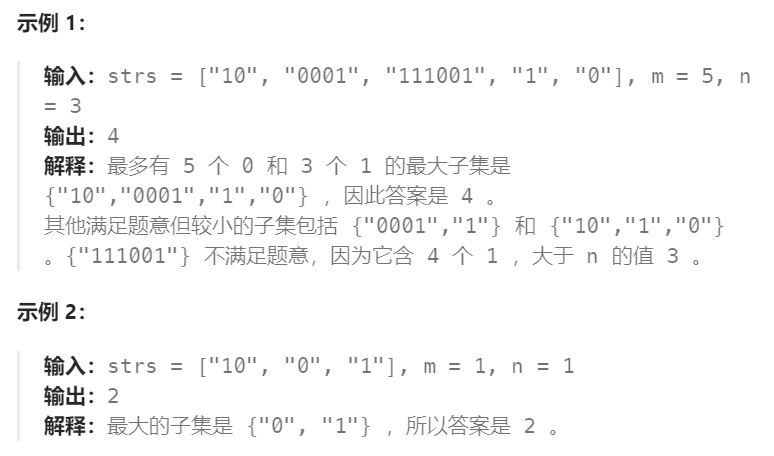

```python
class Solution:
    def findMaxForm(self, strs: List[str], m: int, n: int) -> int:
        dp = [[0] * (n + 1) for _ in range(m + 1)]
        for s in strs:
            one_sum = s.count("1")
            zero_sum = s.count("0")
            for i in range(m, zero_sum -1, -1): # m个0
                for j in range(n, one_sum - 1, -1): # n个1
                    dp[i][j] = max(dp[i][j], dp[i - zero_sum][j - one_sum] + 1)
        return dp[m][n]
```